# Lecture 5: Consumption, investment and equilibrium output

Macro I

Theo Arvanitopoulos

# Learning objectives

### The short-run goods market

- Explain why Keynes focused on spending when output and employment were low.
- Use the consumption function and calculate the marginal propensities to consume and save.
- Distinguish planned from actual investment, including inventory changes.
- Find equilibrium output algebraically and in the Keynesian cross.
- Trace the multiplier and show why saving equals planned investment at equilibrium.

### 📚 Reading

Case, Fair and Oster, *Principles of Macroeconomics*, Chapter 8, especially pp. 170–185.

# Lecture outline

1. **Introduction:** Keynes’s question and the two-sector model.
2. **Consumption and saving:** how households divide income.
3. **Investment:** plans, inventories and the interest rate.
4. **Equilibrium output:** planned expenditure, inventories and $S=I^P$.
5. **The multiplier:** how an investment change alters equilibrium output.

We begin with spending decisions, then bring them together in the goods market.

# Keynes’s question

### The problem

- The Great Depression brought persistent unemployment and sharply lower output.
- Many people were willing to work, but firms were not producing or hiring enough.
- Lower wages alone did not guarantee more jobs: firms also needed customers for the goods additional workers would make.

### Keynes’s intuition

- Firms respond to weak sales by cutting production.
- Workers then receive less income and households spend less, weakening sales further.
- An economy can therefore remain below its productive capacity in the short run.

**The question for this lecture:** how do consumption and investment spending determine output, and what happens when planned spending changes?

# Our starting model

We begin with households and firms in a **closed economy without government**. Households buy consumption goods. Firms buy new capital goods and add to inventories.

$$\boxed{Y=C+I.}$$

Here $Y$ is the value of output and the income it generates, $C$ is consumption, and $I$ is **actual investment**, including changes in inventories. This is an accounting identity for this simplified economy.

Firms also make **plans**. Their planned investment $I^P$ may differ from actual investment when sales differ from expectations. We therefore study planned spending $AE=C+I^P$ and ask when it equals output.

# What determines consumption?

Consumption depends on more than current income. A broader relationship is

$$C=C(Y_D,r,W,Y_D^e).$$

- $C$: household consumption of goods and services.
- $Y_D$: **disposable income**, income available after taxes.
- $r$: the **real interest rate**, relevant to borrowing and saving.
- $W$: **wealth**, the value of assets less liabilities.
- $Y_D^e$: **expected future disposable income**.

Higher current income normally raises consumption. Greater wealth or stronger expected income can also support spending. For now, with no taxes, $Y_D=Y$; we hold $r$, $W$ and $Y_D^e$ fixed.

# The consumption function

Keynes’s intuition was that consumption rises with income, but by **less** than the full increase in income. We represent that idea with a straight line:

$$\boxed{C=a+bY=\bar C+bY},\qquad 0<b<1.$$

- $C$: **real consumption**; $Y$: **real current income**.
- $a=\bar C$: **autonomous consumption**, the intercept when $Y=0$. The bar means we hold this part fixed as income changes.
- $b$: the **marginal propensity to consume (MPC)**, or slope. It measures how much consumption rises when income increases by one unit.

For example, $C=50+0.5Y$ has autonomous consumption of 50. A household could finance consumption at zero current income using savings or borrowing. A rise in wealth or expected income changes the intercept, shifting the whole function.

# Marginal propensity to consume

$$MPC=b=\frac{\Delta C}{\Delta Y}.$$

If $C=50+0.5Y$, another £1 of income raises consumption by 50p. The other 50p is saved.

| Income $Y$ | Consumption $C$ | Change in consumption |
| --- | --- | --- |
| 100 | 100 | — |
| 120 | 110 | £10 for £20 more income |

Thus $MPC=10/20=0.5$. The MPC is the **slope**, not the fraction of total income consumed.

# Consumption function

In $C=50+0.5Y$, the intercept is $\bar C=50$ and the slope is $MPC=0.5$. A change in $Y$ moves us **along** the line; a change in autonomous consumption shifts it.

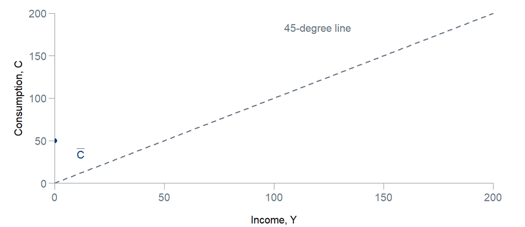

At zero income, consumption equals autonomous consumption, C-bar = 50

# Spending versus saving

At each level of income, households either consume or save:

$$Y=C+S \quad\Rightarrow\quad S=Y-C.$$

Since $\bar C=a$ is consumption **independent of current income**, it reduces saving by the same amount. Substituting $C=\bar C+bY$ gives

$$S=-\bar C+(1-b)Y.$$

At very low current income, saving can be negative.

This is **dissaving**: households consume more than their current income.

In our example, $Y=40$ gives $C=70$ and $S=-30$; at $Y=160$, $C=130$ and $S=30$.

# Marginal propensity to save

The **marginal propensity to save (MPS)** is the part of an **additional** unit of income that households save. Because every extra pound is either consumed or saved,

$$\Delta Y=\Delta C+\Delta S.$$

Dividing through by $\Delta Y$ gives

$$MPS=\frac{\Delta S}{\Delta Y}=1-b=1-MPC.$$

In our example, income rises from 100 to 120. Consumption rises from 100 to 110, so saving rises from 0 to 10. Thus $MPC=10/20=0.5$ and $MPS=10/20=0.5$.

The **average propensity to consume** asks a different question: what share of *total* income is consumed? At $Y=120$, $APC=C/Y=110/120\approx0.917$, while the MPC remains 0.5.

# Saving function

For $C=50+0.5Y$, the saving function is $S=-50+0.5Y$.

Its **intercept** is $-50$ and its **slope** is $MPS=0.5$.

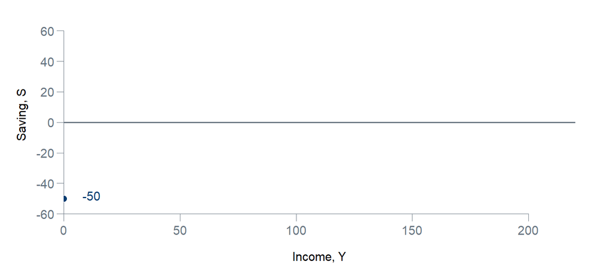

At zero current income, saving is negative

Saving becomes zero at $Y=100$, where consumption exactly equals income.

Below that income, households dissave; above it, saving is positive.

# Consumption and saving together

The 45-degree line in a consumption graph shows $C=Y$.

With $C=50+0.5Y$, compare consumption with that line to read saving directly from $S=Y-C$:

| Income $Y$ | Consumption $C$ | Saving $S$ | Relative to the 45-degree line |
| --- | --- | --- | --- |
| 40 | 70 | $-30$ | Above the 45-degree line |
| 100 | 100 | 0 | On the line |
| 160 | 130 | 30 | Below the line |

- At $Y=40$, households dissave; at $Y=160$, they save part of their income.
- A rise in wealth or expected future income can shift consumption upward.
- At a **given** current income, saving then falls by the same amount.

# Investment in this model

In national accounts, investment is spending on **newly produced capital goods**, residential construction and additions to inventories.

- A firm buying a **new machine** adds to productive capital.
- Building a **new house** counts as residential investment.
- Goods produced but not sold this period add to **inventories**.

$$I=I(r, Y, technology)$$

# Investment in this model

In national accounts, investment is spending on **newly produced capital goods**, residential construction and additions to inventories.

- A firm buying a **new machine** adds to productive capital.
- Building a **new house** counts as residential investment.
- Goods produced but not sold this period add to **inventories**.

$$I=I(r, Y, technology)$$

Buying a share in an existing firm is a financial transaction; it does not itself produce a new machine or house.

Planned investment responds to expected sales, technology and the cost of finance.

We first hold those influences fixed, writing $I^P=\bar I$, where the bar indicates a fixed level of planned investment.

# Autonomous planned investment

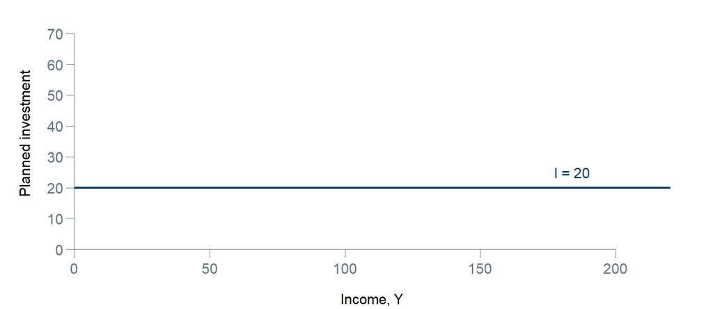

Planned investment is held at 20 for every current income

The flat line is an assumption: **changes in current income do not directly change planned investment here**.

Firms can still revise their plans, moving the whole line.

Autonomous investment $I=\bar{I}$

# Investment and the interest rate

A higher real interest rate makes borrowing dearer and raises the return an investment project must earn. Fewer projects may be worthwhile.

$$I^P=I_0-\gamma r,\qquad \gamma>0.$$

- $I_0$ is planned investment at a zero real interest rate
- $-\gamma=\Delta I^P/\Delta r$ is the change in planned investment for a **one-unit** change in the interest-rate measure.
- This slope is not an elasticity. We use $\gamma$ so that $b$ continues to mean the MPC.

The straight-line equation gives one simple approximation. The next graph allows sensitivity to vary along the schedule. When solving for output later, we hold $r$ fixed, so $I^P=\bar I$.

# Investment schedule

When the real interest rate rises, fewer projects cover their financing cost. The movement from 3% to 6% in the graph reduces planned investment from 100 to 60. A better profit outlook shifts the schedule to the right: firms plan more investment **at the same interest rate**.

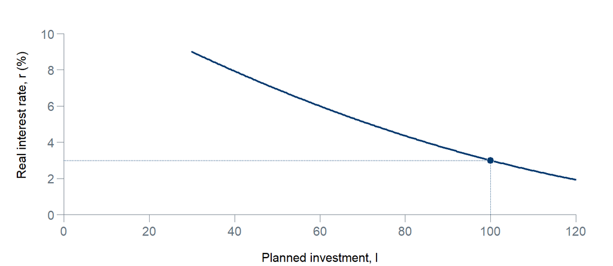

At a real interest rate of 3%, planned investment is 100

# Planned and actual investment

Firms decide how much to produce before they know exactly how much customers will buy. The resulting inventory change can therefore differ from their plan.

$$I^A=I^P+\Delta\text{inventories}^{U},\qquad
\Delta\text{inventories}^{U}=Y-AE.$$

- $I^P$: **planned investment**, including intended additions to inventories.
- $\Delta\text{inventories}^{U}$: the **unplanned** change in inventories when sales differ from plans.
- $I^A$: **actual investment**, including both planned and unplanned changes.

If $AE>Y$, firms sell more than they produced and inventories fall unexpectedly.

If $AE<Y$, inventories rise unexpectedly. These signals help firms decide whether to raise or cut output.

# Planned aggregate expenditure

Planned aggregate expenditure ($AE$) is the amount households and firms **intend** to buy at each level of income. Substitute their behavioural equations into $AE=C+I^P$:

$$C=\bar C+bY,\qquad I^P=\bar I,$$
$$\boxed{AE(Y)=\underbrace{\bar C+\bar I}_{\text{autonomous
spending}}+\underbrace{bY}_{\text{induced consumption}}.}$$

This expression gives planned demand at **any** level of output. $\bar C+\bar I$ is spending independent of current income. The term $bY$ rises with income; its slope is the MPC, $b$.

At equilibrium, output supplied equals planned demand:

$$\underbrace{Y}_{\text{output supplied}}
=\underbrace{(\bar C+\bar I)+bY}_{\text{planned demand for goods}}.$$

This expenditure schedule is not the aggregate-demand curve relating a price level to output.

# From consumption to expenditure

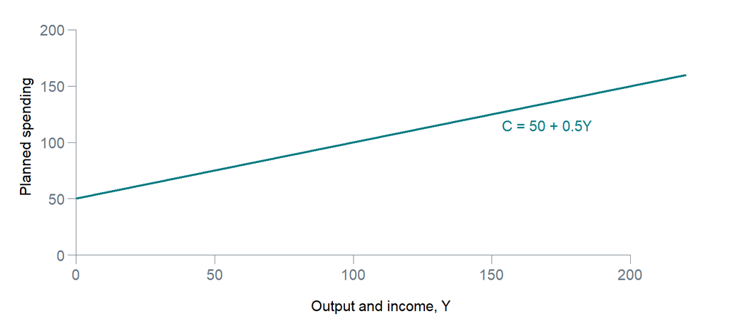

Start with consumption, C = 50 + 0.5Y

# Equilibrium output

Goods-market equilibrium requires firms’ output to match **planned** purchases:

$$Y=AE=C+I^P.$$

On a Keynesian cross, the 45-degree line records $AE=Y$. Equilibrium lies where the planned-expenditure line crosses it.

If $AE>Y$, inventories fall unexpectedly and firms have an incentive to produce more. If $AE<Y$, inventories rise unexpectedly and firms tend to cut production.

# The Keynesian cross

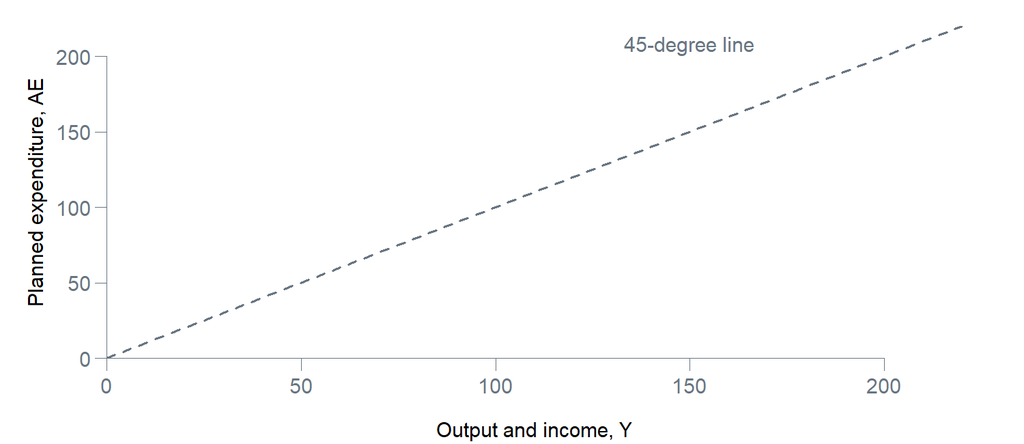

The 45-degree line shows spending equal to output

# Away from equilibrium

Suppose output is $Y=100$. Planned spending is $70+0.5(100)=120$.

Customers want more than firms produce, so inventories fall unexpectedly by 20 and firms expand.

At $Y=180$, planned spending is $160$.

Unsold goods add 20 to inventories; firms tend to reduce production.

These inventory signals move output **towards** the intersection.

In reality the adjustment takes time; the diagram captures its direction.

# Inventory adjustment

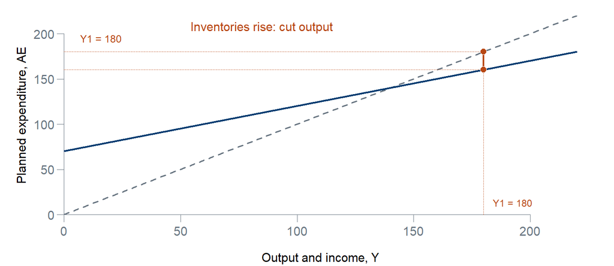

At Y1 = 180, inventories rise by 20; firms cut output

# Numerical example

Recall the general relationships before substituting numbers:

$$AE(Y)=\bar C+bY+\bar I,\qquad
\Delta\text{inventories}^{U}=Y-AE(Y),\qquad
I^A=I^P+\Delta\text{inventories}^{U}.$$

Now let $\bar C=50$, $b=0.5$, $\bar I=20$, and initial output $Y_0=100$. Planned spending is

$$AE(Y_0)=\bar C+bY_0+\bar I=50+0.5(100)+20=120.$$

Firms sell 20 more than expected, so **unplanned inventories fall by 20**:

$$\Delta\text{inventories}^{U}=Y_0-AE_0=100-120=-20.$$

With $I^P=20$, actual investment is $I^A=20-20=0$. Firms have an incentive to raise output. What happens to consumption as income rises?

# The first rounds of adjustment

The initial spending gap tells firms how much more to produce. The higher output becomes household income, which changes consumption according to the MPC:

$$\Delta Y_1=AE(Y_0)-Y_0=20,\qquad
\Delta C_1=b\Delta Y_1=0.5(20)=10.$$

Planned spending therefore rises again: $AE(Y_1)=AE(Y_0)+\Delta C_1=130$.

| Round | Output $Y$ | Planned expenditure $AE=70+0.5Y$ | Gap $AE-Y$ |
| --- | --- | --- | --- |
| Initial | 100 | 120 | 20 |
| After first response | 120 | 130 | 10 |
| After second response | 130 | 135 | 5 |
| After third response | 135 | 137.5 | 2.5 |

The gap shrinks because each additional round of consumption is only half the preceding increase in income.

# Equilibrium by substitution

At equilibrium, $Y=AE(Y)$. Write the general equation first, then substitute the numbers:

$$Y=\bar C+bY+\bar I
\quad\Rightarrow\quad
Y=50+0.5Y+20.$$

$$0.5Y=70\quad\Rightarrow\quad Y^*=140.$$

Check: $C(140)=120$, $I^P=20$, and $AE=120+20=140$. Planned purchases exactly match output. Unplanned inventory investment is zero.

# Saving and investment at equilibrium

Household income is either consumed or saved: $Y=C+S$.

Goods-market equilibrium requires planned purchases to equal output: $Y=C+I^P$.

Subtract $C$ from both equalities:

$$\boxed{S=I^P \quad\text{at goods-market equilibrium}.}$$

At other output levels, **actual** investment can still equal saving in the national accounts because actual investment includes unplanned inventory changes.

The condition here concerns **planned investment**.

# Saving equals planned investment

Using the worked example, $S=-50+0.5Y$ and $I^P=20$.

Their intersection is at $Y=140$, the same output as in the Keynesian cross.

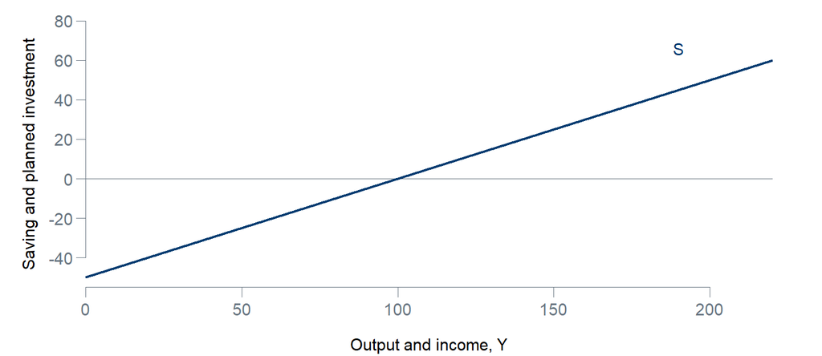

Saving rises with income

# Equilibrium formula

The numerical example gave $Y^*=140$.

To solve **any** version of this simple model, begin with the equilibrium condition and collect the terms in $Y$:

$$Y=\bar C+bY+\bar I
\quad\Rightarrow\quad
(1-b)Y=\bar C+\bar I.$$

$$\boxed{Y^*=\frac{1}{1-b}\,(\bar C+\bar I).}$$

The bracket is **autonomous planned spending**. The factor $1/(1-b)$ tells us how much equilibrium output corresponds to one unit of that spending.

With $\bar C=50$, $\bar I=20$, and $b=0.5$, it gives $Y^*=2(70)=140$.

# A change in planned investment

Keep $\bar C=50$ and $b=0.5$, but let firms raise their **fixed planned investment** from $\bar I_0=20$ to $\bar I_1=40$. Define its change before using it:

$$\Delta\bar I\equiv\bar I_1-\bar I_0=40-20=20.$$

The bar means this part of investment does **not** depend on current income in our model. A rise in $\bar I$ shifts planned expenditure up by 20 at every $Y$:

$$AE_0(Y)=70+0.5Y,\qquad AE_1(Y)=90+0.5Y.$$

# Repeated spending rounds

At the old equilibrium $Y_0^*=140$, the extra investment first raises planned spending by 20. When firms produce the additional goods, income rises, generating more consumption:

$$\Delta Y=20+0.5(20)+0.5^2(20)+\cdots
=20+10+5+2.5+\cdots.$$

Each round is half the previous one because $MPC=b=0.5$. This short calculation makes the multiplier mechanism visible without following every inventory adjustment indefinitely.

In general, $\Delta Y=\Delta\bar I(1+b+b^2+\cdots)$. Since $0<b<1$, the sequence converges.

# Multiplier formula

The geometric sum gives the change in equilibrium output:

$$\boxed{\Delta Y^*=\frac{1}{1-b}\,\Delta\bar I
=\frac{1}{MPS}\,\Delta\bar I.}$$

Here $b=0.5$, so the multiplier is $1/(1-0.5)=2$.

Thus $\Delta Y^*=2(20)=40$, and the new equilibrium is $Y_1^*=140+40=180$.

Check with the general level formula: $Y_1^*=[1/(1-0.5)](50+40)=180$. Both methods give the same result.

### Check your understanding

If $C=60+0.75Y$ and $I^P=40$, find equilibrium output and the multiplier. What would an unexpected rise in inventories tell firms?

# The multiplier in the Keynesian cross

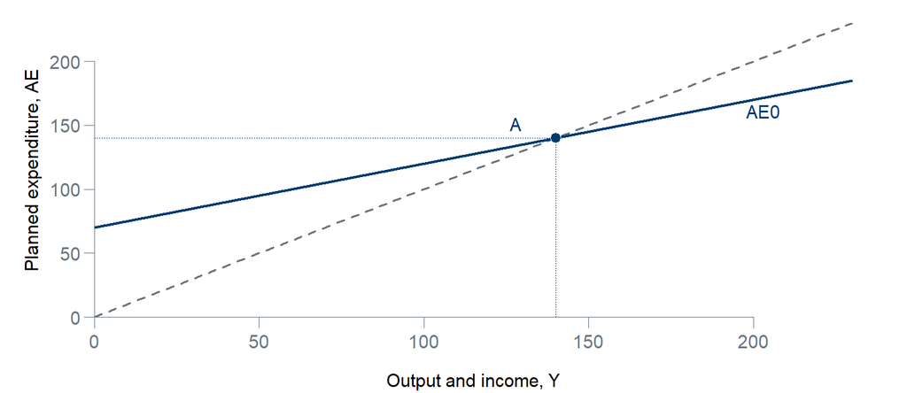

A: the original equilibrium is Y = 140 with planned investment of 20